# Project3

### How to reduce this loss i.e need to reduce False Negatives?

- `recall` should be maximized, the greater the recall higher the chances of minimizing the false negatives.

#### First, let's create functions to calculate different metrics and confusion matrix so that we don't have to use the same code repeatedly for each model.

- The model_performance_classification_sklearn function will be used to check the model performance of models.
- The make_confusion_matrix function will be used to plot confusion matrix.

```python
# defining a function to compute different metrics to check performance of a classification model built using sklearn
def model_performance_classification_sklearn(model, predictors, target):
    """
    Function to compute different metrics to check classification model performance

    model: classifier
    predictors: independent variables
    target: dependent variable
    """

    # predicting using the independent variables
    pred = model.predict(predictors)

    acc = accuracy_score(target, pred)  # to compute Accuracy
    recall = recall_score(target, pred)  # to compute Recall
    precision = precision_score(target, pred)  # to compute Precision
    f1 = f1_score(target, pred)  # to compute F1-score

    # creating a dataframe of metrics
    df_perf = pd.DataFrame(
        {"Accuracy": acc, "Recall": recall, "Precision": precision, "F1": f1,},
        index=[0],
    )

    return df_perf
```

```python
def confusion_matrix_sklearn(model, predictors, target):
    """
    To plot the confusion_matrix with percentages

    model: classifier
    predictors: independent variables
    target: dependent variable
    """
    y_pred = model.predict(predictors)
    cm = confusion_matrix(target, y_pred)
    labels = np.asarray(
        [
            ["{0:0.0f}".format(item) + "\n{0:.2%}".format(item / cm.flatten().sum())]
            for item in cm.flatten()
        ]
    ).reshape(2, 2)

    plt.figure(figsize=(6, 4))
    sns.heatmap(cm, annot=labels, fmt="")
    plt.ylabel("True label")
    plt.xlabel("Predicted label")
```

- #### Copy the dataset, keep the useful columns and create dummies for categorical variables

```python
# Make a copy of the dataset that we preppped for analysis
loan_dt = loan.copy()

# Drop the columns that we wont be using
loan_dt.drop(
    columns=["ageGroup", "incomeGroup", "spendingGroup", "mortgageTaken"], inplace=True,
)
# Creating dummy variables
loan_dt = pd.get_dummies(
    loan_dt, columns=["region", "family", "education"], drop_first=True,
)
loan_dt.head()
```

|  | age | experience | income | ccavg | mortgage | personal_loan | securities_account | cd_account | online | creditcard | region_Inland_Empire | region_Los_Angeles_County | region_North_Coast | region_Orange_County | region_San_Diego-Imperial | region_San_Francisco_Bay_Area | region_San_Joaquin_Valley | region_Superior_California | family_2 | family_3 | family_4 | education_2 | education_3 |
| --- | --- | --- | --- | --- | --- | --- | --- | --- | --- | --- | --- | --- | --- | --- | --- | --- | --- | --- | --- | --- | --- | --- | --- |
| 0 | 25 | 1.0 | 49 | 1.6 | 0 | 0 | 1 | 0 | 0 | 0 | 0 | 1 | 0 | 0 | 0 | 0 | 0 | 0 | 0 | 0 | 1 | 0 | 0 |
| 1 | 45 | 19.0 | 34 | 1.5 | 0 | 0 | 1 | 0 | 0 | 0 | 0 | 1 | 0 | 0 | 0 | 0 | 0 | 0 | 0 | 1 | 0 | 0 | 0 |
| 2 | 39 | 15.0 | 11 | 1.0 | 0 | 0 | 0 | 0 | 0 | 0 | 0 | 0 | 0 | 0 | 0 | 1 | 0 | 0 | 0 | 0 | 0 | 0 | 0 |
| 3 | 35 | 9.0 | 100 | 2.7 | 0 | 0 | 0 | 0 | 0 | 0 | 0 | 0 | 0 | 0 | 0 | 1 | 0 | 0 | 0 | 0 | 0 | 1 | 0 |
| 4 | 35 | 8.0 | 45 | 1.0 | 0 | 0 | 0 | 0 | 0 | 1 | 0 | 1 | 0 | 0 | 0 | 0 | 0 | 0 | 0 | 0 | 1 | 1 | 0 |

- #### Split dataset into test and train data

```python
# Split the dataset into independent variables and dependent variables
X = loan_dt.drop(["personal_loan"], axis=1)
Y = loan_dt["personal_loan"]

# Split the independent and dependent variables into test and training datasets
X_train, X_test, Y_train, Y_test = train_test_split(X, Y, test_size=0.3, random_state=1)

# Show the number of entries in test and train datasets
print("Number of rows in train data =", X_train.shape[0])
print("Number of rows in test data =", X_test.shape[0])

# Get the proportion of loan campaign accepted vs not accepted
print("\nPercentage of classes in training set:")
print(Y_train.value_counts(normalize=True))
print("Percentage of classes in test set:")
print(Y_test.value_counts(normalize=True))
```

```
Number of rows in train data = 3500
Number of rows in test data = 1500

Percentage of classes in training set:
0    0.905429
1    0.094571
Name: personal_loan, dtype: float64
Percentage of classes in test set:
0    0.900667
1    0.099333
Name: personal_loan, dtype: float64
```

- #### A quick glimpse at the column names

```python
loan_dt.columns
```

```
Index(['age', 'experience', 'income', 'ccavg', 'mortgage', 'personal_loan',
       'securities_account', 'cd_account', 'online', 'creditcard',
       'region_Inland_Empire', 'region_Los_Angeles_County',
       'region_North_Coast', 'region_Orange_County',
       'region_San_Diego-Imperial', 'region_San_Francisco_Bay_Area',
       'region_San_Joaquin_Valley', 'region_Superior_California', 'family_2',
       'family_3', 'family_4', 'education_2', 'education_3'],
      dtype='object')
```

- ### First most basic Decison Tree model

```python
model = DecisionTreeClassifier(
    criterion="gini", random_state=1, class_weight="balanced"
)
model.fit(X_train, Y_train)
```

```
DecisionTreeClassifier(class_weight='balanced', random_state=1)
```

- #### Evaluate its performance on the training data

```python
decision_tree_perf_train = model_performance_classification_sklearn(
    model, X_train, Y_train
)
decision_tree_perf_train
```

|  | Accuracy | Recall | Precision | F1 |
| --- | --- | --- | --- | --- |
| 0 | 1.0 | 1.0 | 1.0 | 1.0 |

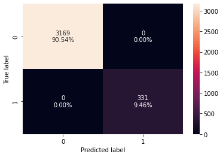

```python
confusion_matrix_sklearn(model, X_train, Y_train)
```

- The model is clearly overfitting as it has very clearly identified True Positive and True Negative.
- There are no False Positive or False Negatives
- #### Evaluate its performance on the test data

```python
decision_tree_perf_test = model_performance_classification_sklearn(
    model, X_test, Y_test
)
decision_tree_perf_test
```

|  | Accuracy | Recall | Precision | F1 |
| --- | --- | --- | --- | --- |
| 0 | 0.976 | 0.845638 | 0.906475 | 0.875 |

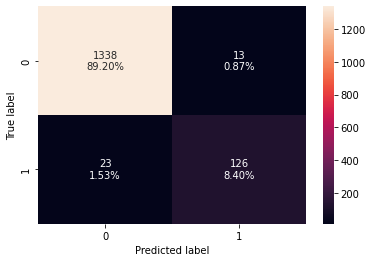

```python
confusion_matrix_sklearn(model, X_test, Y_test)
```

- On the test data we are getting a recall of 0.84 which is very different from training recall of 1.
- Hence we need to tune our model in the next steps
- #### Visualize the Decision Tree

```python
## creating a list of column names
feature_names = X_train.columns.to_list()
```

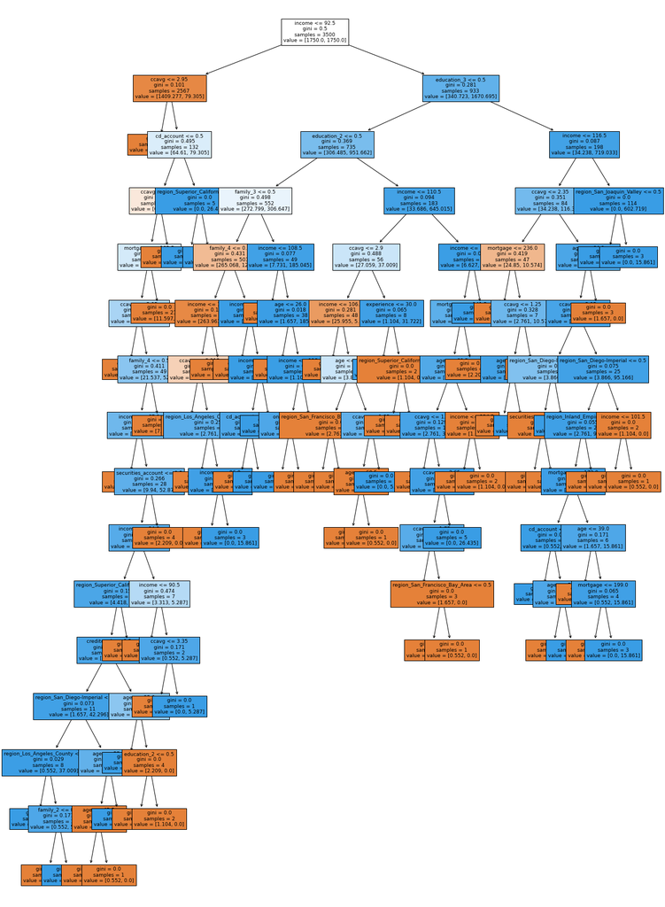

```python
plt.figure(figsize=(20, 30))
out = tree.plot_tree(
    model,
    feature_names=feature_names,
    filled=True,
    fontsize=9,
    node_ids=False,
    class_names=None,
)
# below code will add arrows to the decision tree split if they are missing
for o in out:
    arrow = o.arrow_patch
    if arrow is not None:
        arrow.set_edgecolor("black")
        arrow.set_linewidth(1)
plt.show()
```

```python
# Text report showing the rules of a decision tree -

print(tree.export_text(model, feature_names=feature_names, show_weights=True))
```

```
|--- income <= 92.50
|   |--- ccavg <= 2.95
|   |   |--- weights: [1344.67, 0.00] class: 0
|   |--- ccavg >  2.95
|   |   |--- cd_account <= 0.50
|   |   |   |--- ccavg <= 3.95
|   |   |   |   |--- mortgage <= 102.50
|   |   |   |   |   |--- ccavg <= 3.05
|   |   |   |   |   |   |--- weights: [8.28, 0.00] class: 0
|   |   |   |   |   |--- ccavg >  3.05
|   |   |   |   |   |   |--- family_4 <= 0.50
|   |   |   |   |   |   |   |--- income <= 67.00
|   |   |   |   |   |   |   |   |--- weights: [4.42, 0.00] class: 0
|   |   |   |   |   |   |   |--- income >  67.00
|   |   |   |   |   |   |   |   |--- securities_account <= 0.50
|   |   |   |   |   |   |   |   |   |--- income <= 84.00
|   |   |   |   |   |   |   |   |   |   |--- region_Superior_California <= 0.50
|   |   |   |   |   |   |   |   |   |   |   |--- truncated branch of depth 5
|   |   |   |   |   |   |   |   |   |   |--- region_Superior_California >  0.50
|   |   |   |   |   |   |   |   |   |   |   |--- weights: [0.55, 0.00] class: 0
|   |   |   |   |   |   |   |   |   |--- income >  84.00
|   |   |   |   |   |   |   |   |   |   |--- income <= 90.50
|   |   |   |   |   |   |   |   |   |   |   |--- weights: [2.76, 0.00] class: 0
|   |   |   |   |   |   |   |   |   |   |--- income >  90.50
|   |   |   |   |   |   |   |   |   |   |   |--- truncated branch of depth 2
|   |   |   |   |   |   |   |   |--- securities_account >  0.50
|   |   |   |   |   |   |   |   |   |--- weights: [2.21, 0.00] class: 0
|   |   |   |   |   |   |--- family_4 >  0.50
|   |   |   |   |   |   |   |--- weights: [7.18, 0.00] class: 0
|   |   |   |   |--- mortgage >  102.50
|   |   |   |   |   |--- weights: [11.60, 0.00] class: 0
|   |   |   |--- ccavg >  3.95
|   |   |   |   |--- weights: [23.19, 0.00] class: 0
|   |   |--- cd_account >  0.50
|   |   |   |--- region_Superior_California <= 0.50
|   |   |   |   |--- weights: [0.00, 21.15] class: 1
|   |   |   |--- region_Superior_California >  0.50
|   |   |   |   |--- weights: [0.00, 5.29] class: 1
|--- income >  92.50
|   |--- education_3 <= 0.50
```

[output cut: 135 more lines]

```
|   |   |   |   |   |   |   |   |   |   |   |--- weights: [0.00, 15.86] class: 1
|   |   |   |   |   |   |   |--- region_Inland_Empire >  0.50
|   |   |   |   |   |   |   |   |--- weights: [0.55, 0.00] class: 0
|   |   |   |   |   |   |--- region_San_Diego-Imperial >  0.50
|   |   |   |   |   |   |   |--- income <= 101.50
|   |   |   |   |   |   |   |   |--- weights: [0.55, 0.00] class: 0
|   |   |   |   |   |   |   |--- income >  101.50
|   |   |   |   |   |   |   |   |--- weights: [0.55, 0.00] class: 0
|   |   |   |   |--- age >  64.00
|   |   |   |   |   |--- weights: [1.66, 0.00] class: 0
|   |   |--- income >  116.50
|   |   |   |--- region_San_Joaquin_Valley <= 0.50
|   |   |   |   |--- weights: [0.00, 586.86] class: 1
|   |   |   |--- region_San_Joaquin_Valley >  0.50
|   |   |   |   |--- weights: [0.00, 15.86] class: 1
```

- #### Display the importance of the features

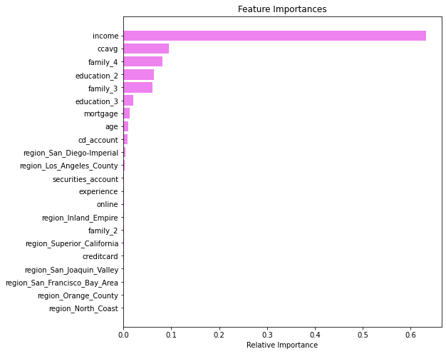

```python
importances = model.feature_importances_
indices = np.argsort(importances)

plt.figure(figsize=(8, 8))
plt.title("Feature Importances")
plt.barh(range(len(indices)), importances[indices], color="violet", align="center")
plt.yticks(range(len(indices)), [feature_names[i] for i in indices])
plt.xlabel("Relative Importance")
plt.show()
```

- In the default model, Income of the customer is the most signifcant feature which decides if the customer will take out a loan
- Following that family, credit card usage and education are also important

### Using GridSearch for Hyperparameter tuning of our tree model

```python
#  Choose the type of classifier.
estimator = DecisionTreeClassifier(random_state=1, class_weight="balanced")

# Grid of parameters to choose from
parameters = {
    "max_depth": [5, 10, 15, 20, 25, None],
    "criterion": ["entropy", "gini"],
    "splitter": ["best", "random"],
    "min_impurity_decrease": [1e-6, 1e-5, 1e-4, 1e-3, 1e-2, 1e-1],
}

# Type of scoring used to compare parameter combinations
scorer = make_scorer(recall_score)

# Run the grid search
grid_obj = GridSearchCV(estimator, parameters, scoring=scorer, cv=5)
grid_obj = grid_obj.fit(X_train, Y_train)

# Set the clf to the best combination of parameters
estimator = grid_obj.best_estimator_

# Fit the best algorithm to the data.
estimator.fit(X_train, Y_train)
```

```
DecisionTreeClassifier(class_weight='balanced', max_depth=5,
                       min_impurity_decrease=0.01, random_state=1)
```

- #### Evaluate its performance on the training data

```python
decision_tree_preprune_perf_train = model_performance_classification_sklearn(
    estimator, X_train, Y_train
)
decision_tree_preprune_perf_train
```

|  | Accuracy | Recall | Precision | F1 |
| --- | --- | --- | --- | --- |
| 0 | 0.926 | 0.990937 | 0.561644 | 0.71694 |

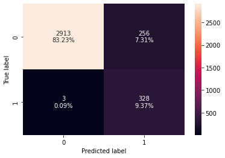

```python
confusion_matrix_sklearn(estimator, X_train, Y_train)
```

```python
decision_tree_preprune_perf_test = model_performance_classification_sklearn(
    estimator, X_test, Y_test
)
decision_tree_preprune_perf_test
```

|  | Accuracy | Recall | Precision | F1 |
| --- | --- | --- | --- | --- |
| 0 | 0.93 | 0.979866 | 0.58871 | 0.735516 |

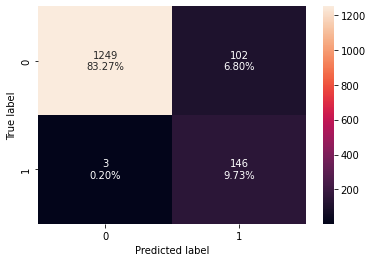

```python
confusion_matrix_sklearn(estimator, X_test, Y_test)
```

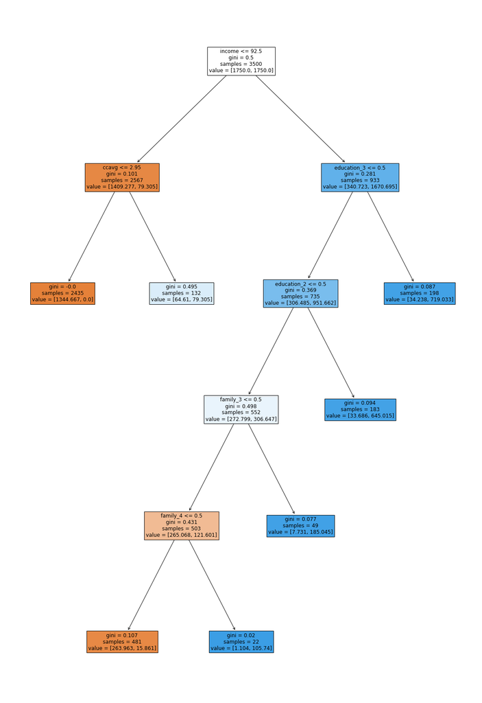

```python
plt.figure(figsize=(20, 30))
out = tree.plot_tree(
    estimator,
    feature_names=feature_names,
    filled=True,
    fontsize=12,
    node_ids=False,
    class_names=None,
)
# below code will add arrows to the decision tree split if they are missing
for o in out:
    arrow = o.arrow_patch
    if arrow is not None:
        arrow.set_edgecolor("black")
        arrow.set_linewidth(1)
plt.show()
```

```python
# Text report showing the rules of a decision tree -

print(tree.export_text(estimator, feature_names=feature_names, show_weights=True))
```

```
|--- income <= 92.50
|   |--- ccavg <= 2.95
|   |   |--- weights: [1344.67, 0.00] class: 0
|   |--- ccavg >  2.95
|   |   |--- weights: [64.61, 79.31] class: 1
|--- income >  92.50
|   |--- education_3 <= 0.50
|   |   |--- education_2 <= 0.50
|   |   |   |--- family_3 <= 0.50
|   |   |   |   |--- family_4 <= 0.50
|   |   |   |   |   |--- weights: [263.96, 15.86] class: 0
|   |   |   |   |--- family_4 >  0.50
|   |   |   |   |   |--- weights: [1.10, 105.74] class: 1
|   |   |   |--- family_3 >  0.50
|   |   |   |   |--- weights: [7.73, 185.05] class: 1
|   |   |--- education_2 >  0.50
|   |   |   |--- weights: [33.69, 645.02] class: 1
|   |--- education_3 >  0.50
|   |   |--- weights: [34.24, 719.03] class: 1
```

- #### Display the importance of the features

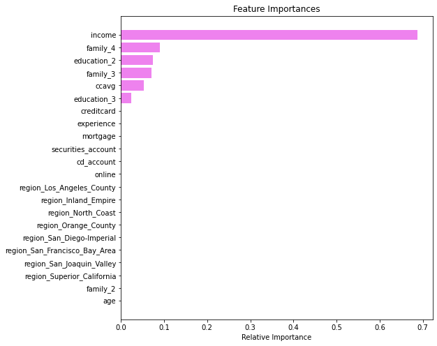

```python
importances = estimator.feature_importances_
indices = np.argsort(importances)

plt.figure(figsize=(8, 8))
plt.title("Feature Importances")
plt.barh(range(len(indices)), importances[indices], color="violet", align="center")
plt.yticks(range(len(indices)), [feature_names[i] for i in indices])
plt.xlabel("Relative Importance")
plt.show()
```

- Again in the pre pruuned model, Income of the customer is the most signifcant feature which decides if the customer will take out a loan
- Following that family, credit card usage and education are also important

### Cost Complexity Pruning

```python
clf = DecisionTreeClassifier(random_state=1, class_weight="balanced")
path = clf.cost_complexity_pruning_path(X_train, Y_train)
ccp_alphas, impurities = path.ccp_alphas, path.impurities
```

```python
pd.DataFrame(path)
```

|  | ccp_alphas | impurities |
| --- | --- | --- |
| 0 | 0.000000e+00 | -6.604119e-15 |
| 1 | 3.853725e-19 | -6.603733e-15 |
| 2 | 3.853725e-19 | -6.603348e-15 |
| 3 | 3.853725e-19 | -6.602963e-15 |
| 4 | 4.729571e-19 | -6.602490e-15 |
| 5 | 5.255079e-19 | -6.601964e-15 |
| 6 | 5.255079e-19 | -6.601439e-15 |
| 7 | 7.707449e-19 | -6.600668e-15 |
| 8 | 7.882619e-19 | -6.599880e-15 |
| 9 | 1.961896e-18 | -6.597918e-15 |
| 10 | 1.257806e-17 | -6.585340e-15 |
| 11 | 1.338305e-16 | -6.451509e-15 |
| 12 | 1.554588e-04 | 3.109177e-04 |
| 13 | 1.566874e-04 | 6.242925e-04 |
| 14 | 1.569588e-04 | 9.382100e-04 |
| 15 | 2.857143e-04 | 1.223924e-03 |
| 16 | 2.998950e-04 | 1.523819e-03 |
| 17 | 3.000356e-04 | 2.123890e-03 |
| 18 | 3.049400e-04 | 2.428831e-03 |
| 19 | 3.049400e-04 | 2.733771e-03 |
| 20 | 3.049944e-04 | 3.648754e-03 |
| 21 | 3.106726e-04 | 3.959426e-03 |
| 22 | 3.127569e-04 | 4.897697e-03 |
| 23 | 4.530549e-04 | 5.803807e-03 |
| 24 | 4.663329e-04 | 7.202806e-03 |
| 25 | 5.220569e-04 | 7.724862e-03 |
| 26 | 5.621342e-04 | 8.286997e-03 |
| 27 | 5.893791e-04 | 8.876376e-03 |
| 28 | 6.098801e-04 | 9.486256e-03 |
| 29 | 6.292497e-04 | 1.074476e-02 |
| 30 | 7.539183e-04 | 1.149867e-02 |
| 31 | 7.592044e-04 | 1.377629e-02 |
| 32 | 9.269294e-04 | 1.470322e-02 |
| 33 | 9.347864e-04 | 1.750758e-02 |
| 34 | 9.511997e-04 | 1.845877e-02 |
| 35 | 1.038905e-03 | 1.949768e-02 |
| 36 | 1.233904e-03 | 2.073158e-02 |
| 37 | 1.671123e-03 | 2.240271e-02 |
| 38 | 2.221376e-03 | 2.684546e-02 |
| 39 | 2.375809e-03 | 2.922127e-02 |
| 40 | 2.987590e-03 | 3.220886e-02 |
| 41 | 3.302354e-03 | 3.551121e-02 |
| 42 | 3.344493e-03 | 3.885570e-02 |
| 43 | 3.602932e-03 | 4.606157e-02 |
| 44 | 3.729690e-03 | 4.979126e-02 |
| 45 | 4.754778e-03 | 5.930081e-02 |
| 46 | 5.713990e-03 | 7.072880e-02 |
| 47 | 2.255792e-02 | 9.328672e-02 |
| 48 | 2.783350e-02 | 2.046207e-01 |
| 49 | 2.953793e-01 | 5.000000e-01 |

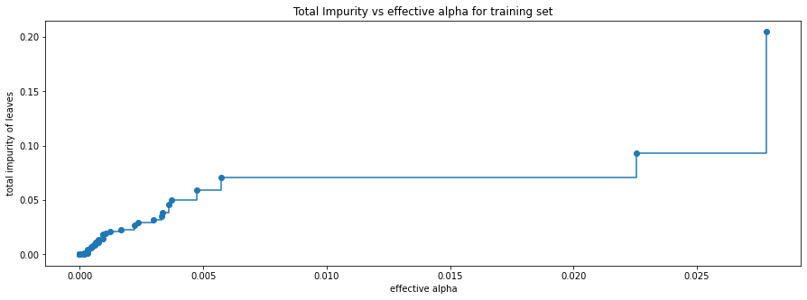

```python
fig, ax = plt.subplots(figsize=(15, 5))
ax.plot(ccp_alphas[:-1], impurities[:-1], marker="o", drawstyle="steps-post")
ax.set_xlabel("effective alpha")
ax.set_ylabel("total impurity of leaves")
ax.set_title("Total Impurity vs effective alpha for training set")
plt.show()
```

Next, we train a decision tree using the effective alphas. The last value in `ccp_alphas` is the alpha value that prunes the whole tree, leaving the tree, `clfs[-1]`, with one node.

```python
clfs = []
for ccp_alpha in ccp_alphas:
    clf = DecisionTreeClassifier(
        random_state=1, ccp_alpha=ccp_alpha, class_weight="balanced"
    )
    clf.fit(X_train, Y_train)
    clfs.append(clf)
print(
    "Number of nodes in the last tree is: {} with ccp_alpha: {}".format(
        clfs[-1].tree_.node_count, ccp_alphas[-1]
    )
)
```

```
Number of nodes in the last tree is: 1 with ccp_alpha: 0.29537927599923186
```

For the remainder, we remove the last element in `clfs` and `ccp_alphas`, because it is the trivial tree with only one node. Here we show that the number of nodes and tree depth decreases as alpha increases.

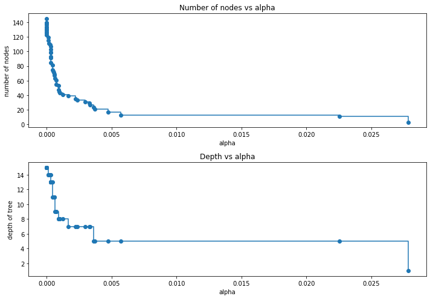

```python
clfs = clfs[:-1]
ccp_alphas = ccp_alphas[:-1]

node_counts = [clf.tree_.node_count for clf in clfs]
depth = [clf.tree_.max_depth for clf in clfs]
fig, ax = plt.subplots(2, 1, figsize=(10, 7))
ax[0].plot(ccp_alphas, node_counts, marker="o", drawstyle="steps-post")
ax[0].set_xlabel("alpha")
ax[0].set_ylabel("number of nodes")
ax[0].set_title("Number of nodes vs alpha")
ax[1].plot(ccp_alphas, depth, marker="o", drawstyle="steps-post")
ax[1].set_xlabel("alpha")
ax[1].set_ylabel("depth of tree")
ax[1].set_title("Depth vs alpha")
fig.tight_layout()
```

- #### Recall vs alpha for training and testing sets

```python
recall_train = []
for clf in clfs:
    pred_train = clf.predict(X_train)
    values_train = recall_score(Y_train, pred_train)
    recall_train.append(values_train)
```

```python
recall_test = []
for clf in clfs:
    pred_test = clf.predict(X_test)
    values_test = recall_score(Y_test, pred_test)
    recall_test.append(values_test)
```

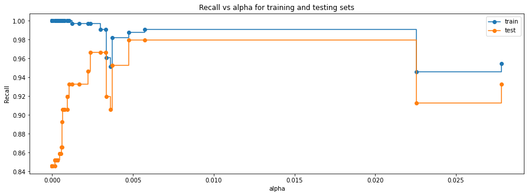

```python
fig, ax = plt.subplots(figsize=(15, 5))
ax.set_xlabel("alpha")
ax.set_ylabel("Recall")
ax.set_title("Recall vs alpha for training and testing sets")
ax.plot(ccp_alphas, recall_train, marker="o", label="train", drawstyle="steps-post")
ax.plot(ccp_alphas, recall_test, marker="o", label="test", drawstyle="steps-post")
ax.legend()
plt.show()
```

```python
# creating the model where we get highest train and test recall
index_best_model = np.argmax(recall_test)
best_model = clfs[index_best_model]
print(best_model)
```

```
DecisionTreeClassifier(ccp_alpha=0.004754778197299548, class_weight='balanced',
                       random_state=1)
```

- #### Checking model performance on training set

```python
decision_tree_postprune_perf_train = model_performance_classification_sklearn(
    best_model, X_train, Y_train
)
decision_tree_postprune_perf_train
```

|  | Accuracy | Recall | Precision | F1 |
| --- | --- | --- | --- | --- |
| 0 | 0.939143 | 0.987915 | 0.610075 | 0.754325 |

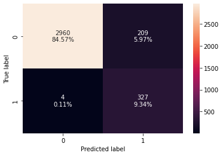

```python
confusion_matrix_sklearn(best_model, X_train, Y_train)
```

```python
decision_tree_postprune_perf_test = model_performance_classification_sklearn(
    best_model, X_test, Y_test
)
decision_tree_postprune_perf_test
```

|  | Accuracy | Recall | Precision | F1 |
| --- | --- | --- | --- | --- |
| 0 | 0.938 | 0.979866 | 0.618644 | 0.758442 |

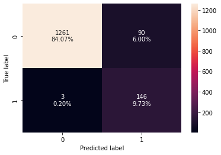

```python
confusion_matrix_sklearn(best_model, X_test, Y_test)
```

- #### Visualize the Decision Tree

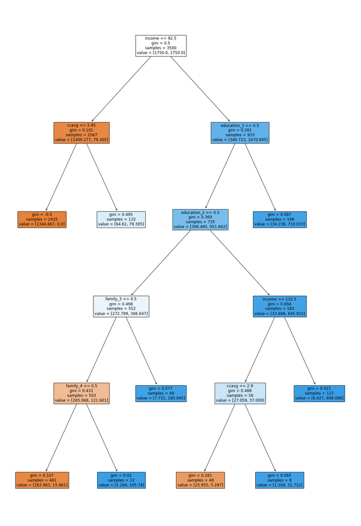

```python
plt.figure(figsize=(20, 30))
out = tree.plot_tree(
    best_model,
    feature_names=feature_names,
    filled=True,
    fontsize=12,
    node_ids=False,
    class_names=None,
)
# below code will add arrows to the decision tree split if they are missing
for o in out:
    arrow = o.arrow_patch
    if arrow is not None:
        arrow.set_edgecolor("black")
        arrow.set_linewidth(1)
plt.show()
```

```python
# Text report showing the rules of a decision tree -

print(tree.export_text(best_model, feature_names=feature_names, show_weights=True))
```

```
|--- income <= 92.50
|   |--- ccavg <= 2.95
|   |   |--- weights: [1344.67, 0.00] class: 0
|   |--- ccavg >  2.95
|   |   |--- weights: [64.61, 79.31] class: 1
|--- income >  92.50
|   |--- education_3 <= 0.50
|   |   |--- education_2 <= 0.50
|   |   |   |--- family_3 <= 0.50
|   |   |   |   |--- family_4 <= 0.50
|   |   |   |   |   |--- weights: [263.96, 15.86] class: 0
|   |   |   |   |--- family_4 >  0.50
|   |   |   |   |   |--- weights: [1.10, 105.74] class: 1
|   |   |   |--- family_3 >  0.50
|   |   |   |   |--- weights: [7.73, 185.05] class: 1
|   |   |--- education_2 >  0.50
|   |   |   |--- income <= 110.50
|   |   |   |   |--- ccavg <= 2.90
|   |   |   |   |   |--- weights: [25.95, 5.29] class: 0
|   |   |   |   |--- ccavg >  2.90
|   |   |   |   |   |--- weights: [1.10, 31.72] class: 1
|   |   |   |--- income >  110.50
|   |   |   |   |--- weights: [6.63, 608.01] class: 1
|   |--- education_3 >  0.50
|   |   |--- weights: [34.24, 719.03] class: 1
```

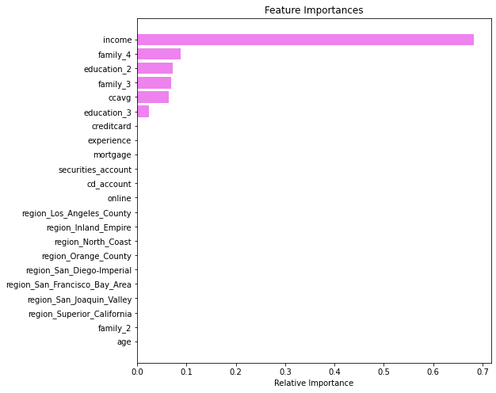

```python
importances = best_model.feature_importances_
indices = np.argsort(importances)

plt.figure(figsize=(8, 8))
plt.title("Feature Importances")
plt.barh(range(len(indices)), importances[indices], color="violet", align="center")
plt.yticks(range(len(indices)), [feature_names[i] for i in indices])
plt.xlabel("Relative Importance")
plt.show()
```

### Comparing all the decision tree models

```python
# training performance comparison

models_train_comp_df = pd.concat(
    [
        decision_tree_perf_train.T,
        decision_tree_preprune_perf_train.T,
        decision_tree_postprune_perf_train.T,
    ],
    axis=1,
)
models_train_comp_df.columns = [
    "Decision Tree sklearn",
    "Decision Tree (Pre-Pruning)",
    "Decision Tree (Post-Pruning)",
]
print("Training performance comparison:")
models_train_comp_df
```

```
Training performance comparison:
```

|  | Decision Tree sklearn | Decision Tree (Pre-Pruning) | Decision Tree (Post-Pruning) |
| --- | --- | --- | --- |
| Accuracy | 1.0 | 0.926000 | 0.939143 |
| Recall | 1.0 | 0.990937 | 0.987915 |
| Precision | 1.0 | 0.561644 | 0.610075 |
| F1 | 1.0 | 0.716940 | 0.754325 |

```python
# test performance comparison

models_train_comp_df = pd.concat(
    [
        decision_tree_perf_test.T,
        decision_tree_preprune_perf_test.T,
        decision_tree_postprune_perf_test.T,
    ],
    axis=1,
)
models_train_comp_df.columns = [
    "Decision Tree sklearn",
    "Decision Tree (Pre-Pruning)",
    "Decision Tree (Post-Pruning)",
]
print("Test set performance comparison:")
models_train_comp_df
```

```
Test set performance comparison:
```

|  | Decision Tree sklearn | Decision Tree (Pre-Pruning) | Decision Tree (Post-Pruning) |
| --- | --- | --- | --- |
| Accuracy | 0.976000 | 0.930000 | 0.938000 |
| Recall | 0.845638 | 0.979866 | 0.979866 |
| Precision | 0.906475 | 0.588710 | 0.618644 |
| F1 | 0.875000 | 0.735516 | 0.758442 |

## 4. **Building Logistic Regression**

### Model evaluation criterion

### Model can make wrong predictions as:

1. A customer to whom the the loan campaign is targeted will not be taking loan but in reality the customer would take the loan.
2. A customer to whom the the loan campaign is targeted will be taking loan but in reality the customer would not take the loan.

### Which case is more important?

- If we predict a prospective customer as not a loan buyer, bank would lose an opportunity of providing loan to a potential customer.

### How to reduce this loss i.e need to reduce False Negatives?

- `recall` should be maximized, the greater the recall higher the chances of minimizing the false negatives.

#### First, let's create functions to calculate different metrics and confusion matrix so that we don't have to use the same code repeatedly for each model.

- The model_performance_classification_sklearn_with_threshold function will be used to check the model performance of models.
- The confusion_matrix_sklearn_with_threshold function will be used to plot confusion matrix.

```python
# defining a function to compute different metrics to check performance of a classification model built using sklearn


def model_performance_classification_sklearn_with_threshold(
    model, predictors, target, threshold=0.5
):
    """
    Function to compute different metrics, based on the threshold specified, to check classification model performance

    model: classifier
    predictors: independent variables
    target: dependent variable
    threshold: threshold for classifying the observation as class 1
    """

    # predicting using the independent variables
    pred_prob = model.predict_proba(predictors)[:, 1]
    pred_thres = pred_prob > threshold
    pred = np.round(pred_thres)

    acc = accuracy_score(target, pred)  # to compute Accuracy
    recall = recall_score(target, pred)  # to compute Recall
    precision = precision_score(target, pred)  # to compute Precision
    f1 = f1_score(target, pred)  # to compute F1-score

    # creating a dataframe of metrics
    df_perf = pd.DataFrame(
        {"Accuracy": acc, "Recall": recall, "Precision": precision, "F1": f1,},
        index=[0],
    )

    return df_perf
```

```python
# defining a function to plot the confusion_matrix of a classification model built using sklearn
def confusion_matrix_sklearn_with_threshold(model, predictors, target, threshold=0.5):
    """
    To plot the confusion_matrix, based on the threshold specified, with percentages

    model: classifier
    predictors: independent variables
    target: dependent variable
    threshold: threshold for classifying the observation as class 1
    """
    pred_prob = model.predict_proba(predictors)[:, 1]
    pred_thres = pred_prob > threshold
    y_pred = np.round(pred_thres)

    cm = confusion_matrix(target, y_pred)
    labels = np.asarray(
        [
            ["{0:0.0f}".format(item) + "\n{0:.2%}".format(item / cm.flatten().sum())]
            for item in cm.flatten()
        ]
    ).reshape(2, 2)

    plt.figure(figsize=(6, 4))
    sns.heatmap(cm, annot=labels, fmt="")
    plt.ylabel("True label")
    plt.xlabel("Predicted label")
```

- #### Copy the dataset, keep the useful columns and create dummies for categorical variables

```python
# Make a copy of the dataset that we preppped for analysis
loan_lr = loan.copy()

# Drop the columns that we wont be using
loan_lr.drop(
    columns=["ageGroup", "incomeGroup", "spendingGroup", "mortgageTaken"], inplace=True,
)
# Creating dummy variables
loan_lr = pd.get_dummies(
    loan_lr, columns=["region", "family", "education"], drop_first=True,
)
loan_lr.head()
```

|  | age | experience | income | ccavg | mortgage | personal_loan | securities_account | cd_account | online | creditcard | region_Inland_Empire | region_Los_Angeles_County | region_North_Coast | region_Orange_County | region_San_Diego-Imperial | region_San_Francisco_Bay_Area | region_San_Joaquin_Valley | region_Superior_California | family_2 | family_3 | family_4 | education_2 | education_3 |
| --- | --- | --- | --- | --- | --- | --- | --- | --- | --- | --- | --- | --- | --- | --- | --- | --- | --- | --- | --- | --- | --- | --- | --- |
| 0 | 25 | 1.0 | 49 | 1.6 | 0 | 0 | 1 | 0 | 0 | 0 | 0 | 1 | 0 | 0 | 0 | 0 | 0 | 0 | 0 | 0 | 1 | 0 | 0 |
| 1 | 45 | 19.0 | 34 | 1.5 | 0 | 0 | 1 | 0 | 0 | 0 | 0 | 1 | 0 | 0 | 0 | 0 | 0 | 0 | 0 | 1 | 0 | 0 | 0 |
| 2 | 39 | 15.0 | 11 | 1.0 | 0 | 0 | 0 | 0 | 0 | 0 | 0 | 0 | 0 | 0 | 0 | 1 | 0 | 0 | 0 | 0 | 0 | 0 | 0 |
| 3 | 35 | 9.0 | 100 | 2.7 | 0 | 0 | 0 | 0 | 0 | 0 | 0 | 0 | 0 | 0 | 0 | 1 | 0 | 0 | 0 | 0 | 0 | 1 | 0 |
| 4 | 35 | 8.0 | 45 | 1.0 | 0 | 0 | 0 | 0 | 0 | 1 | 0 | 1 | 0 | 0 | 0 | 0 | 0 | 0 | 0 | 0 | 1 | 1 | 0 |

- #### Split dataset into test and train data

```python
# Split the dataset into independent variables and dependent variables
X = loan_lr.drop(["personal_loan"], axis=1)
Y = loan_lr["personal_loan"]

# Split the independent and dependent variables into test and training datasets
X_train, X_test, Y_train, Y_test = train_test_split(X, Y, test_size=0.3, random_state=1)

# Show the number of entries in test and train datasets
print("Number of rows in train data =", X_train.shape[0])
print("Number of rows in test data =", X_test.shape[0])

# Get the proportion of loan campaign accepted vs not accepted
print("\nPercentage of classes in training set:")
print(Y_train.value_counts(normalize=True))
print("Percentage of classes in test set:")
print(Y_test.value_counts(normalize=True))
```

```
Number of rows in train data = 3500
Number of rows in test data = 1500

Percentage of classes in training set:
0    0.905429
1    0.094571
Name: personal_loan, dtype: float64
Percentage of classes in test set:
0    0.900667
1    0.099333
Name: personal_loan, dtype: float64
```

- #### A quick glimpse at the column names

```python
loan_lr.columns
```

```
Index(['age', 'experience', 'income', 'ccavg', 'mortgage', 'personal_loan',
       'securities_account', 'cd_account', 'online', 'creditcard',
       'region_Inland_Empire', 'region_Los_Angeles_County',
       'region_North_Coast', 'region_Orange_County',
       'region_San_Diego-Imperial', 'region_San_Francisco_Bay_Area',
       'region_San_Joaquin_Valley', 'region_Superior_California', 'family_2',
       'family_3', 'family_4', 'education_2', 'education_3'],
      dtype='object')
```

- ### Buliding first logisitic regression model

```python
# There are different solvers available in Sklearn logistic regression
# The newton-cg solver is faster for high-dimensional data

model_lr = LogisticRegression(solver="newton-cg", random_state=1)
lr = model_lr.fit(X_train, Y_train)
```

- #### Finding the coefficients

```python
log_odds = lr.coef_[0]
pd.DataFrame(log_odds, X_train.columns, columns=["coef"]).T
```

|  | age | experience | income | ccavg | mortgage | securities_account | cd_account | online | creditcard | region_Inland_Empire | region_Los_Angeles_County | region_North_Coast | region_Orange_County | region_San_Diego-Imperial | region_San_Francisco_Bay_Area | region_San_Joaquin_Valley | region_Superior_California | family_2 | family_3 | family_4 | education_2 | education_3 |
| --- | --- | --- | --- | --- | --- | --- | --- | --- | --- | --- | --- | --- | --- | --- | --- | --- | --- | --- | --- | --- | --- | --- |
| coef | 0.001462 | 0.003634 | 0.056994 | 0.21435 | 0.000813 | -0.719248 | 2.95133 | -0.459515 | -0.765919 | 0.071258 | -0.120147 | -0.048299 | 0.00885 | 0.003037 | -0.095718 | 0.41303 | -0.163568 | -0.127235 | 2.126967 | 1.397812 | 3.339804 | 3.548636 |

```python
# converting coefficients to odds
odds = np.exp(lr.coef_[0])

# finding the percentage change
perc_change_odds = (np.exp(lr.coef_[0]) - 1) * 100

# removing limit from number of columns to display
pd.set_option("display.max_columns", None)

# adding the odds to a dataframe
pd.DataFrame({"Odds": odds, "Change_odd%": perc_change_odds}, index=X_train.columns).T
```

|  | age | experience | income | ccavg | mortgage | securities_account | cd_account | online | creditcard | region_Inland_Empire | region_Los_Angeles_County | region_North_Coast | region_Orange_County | region_San_Diego-Imperial | region_San_Francisco_Bay_Area | region_San_Joaquin_Valley | region_Superior_California | family_2 | family_3 | family_4 | education_2 | education_3 |
| --- | --- | --- | --- | --- | --- | --- | --- | --- | --- | --- | --- | --- | --- | --- | --- | --- | --- | --- | --- | --- | --- | --- |
| Odds | 1.001463 | 1.003641 | 1.058649 | 1.239056 | 1.000813 | 0.487118 | 19.131389 | 0.63159 | 0.464906 | 1.073858 | 0.886790 | 0.952849 | 1.008889 | 1.003042 | 0.908720 | 1.511390 | 0.849109 | 0.880527 | 8.389384 | 4.046337 | 28.213584 | 34.765863 |
| Change_odd% | 0.146294 | 0.364063 | 5.864912 | 23.905640 | 0.081310 | -51.288165 | 1813.138870 | -36.84099 | -53.509369 | 7.385794 | -11.321024 | -4.715140 | 0.888895 | 0.304189 | -9.128008 | 51.138964 | -15.089087 | -11.947317 | 738.938418 | 304.633721 | 2721.358364 | 3376.586317 |

- #### Coefficient interpretations
  - For continuous varaibles like age, experience, income, ccavg, mortgage, a unit increase in each can lead to an increase of customers chance to take out loan by 0.15%, 0.36%, 5.87%, 23.91% and 0.08% respectively
  - For binary variables like securities account, cd_account, online and creditcard, the odds of customer taking out a loan are 51% less if they have securities account, 1813% higher if they have a cd_account, 36% less if they use online banking and 53% less if they use a credit card.
  - For a family of size 3 and 4 the odds of the customer to take out a loan are higher 740% and 304% than single person household
  - Having a graduate degree or a professional/advanced degree increase the odds of the person to take out a loan by 2700% and 3400% respectively
- #### Checking model performance on training set

```python
log_reg_model_train_perf = model_performance_classification_sklearn_with_threshold(
    lr, X_train, Y_train
)

print("Training performance:")
log_reg_model_train_perf
```

```
Training performance:
```

|  | Accuracy | Recall | Precision | F1 |
| --- | --- | --- | --- | --- |
| 0 | 0.962857 | 0.685801 | 0.897233 | 0.777397 |

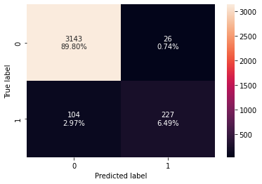

```python
# creating confusion matrix
confusion_matrix_sklearn_with_threshold(lr, X_train, Y_train)
```

- #### Checking model performance on test set

```python
log_reg_model_test_perf = model_performance_classification_sklearn_with_threshold(
    lr, X_test, Y_test
)

print("Test performance:")
log_reg_model_test_perf
```

```
Test performance:
```

|  | Accuracy | Recall | Precision | F1 |
| --- | --- | --- | --- | --- |
| 0 | 0.953333 | 0.597315 | 0.89899 | 0.717742 |

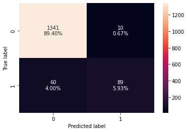

```python
# creating confusion matrix
confusion_matrix_sklearn_with_threshold(lr, X_test, Y_test)
```

- #### ROC-AUC on training set

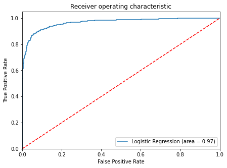

```python
logit_roc_auc_train = roc_auc_score(Y_train, lr.predict_proba(X_train)[:, 1])
fpr, tpr, thresholds = roc_curve(Y_train, lr.predict_proba(X_train)[:, 1])
plt.figure(figsize=(7, 5))
plt.plot(fpr, tpr, label="Logistic Regression (area = %0.2f)" % logit_roc_auc_train)
plt.plot([0, 1], [0, 1], "r--")
plt.xlim([0.0, 1.0])
plt.ylim([0.0, 1.05])
plt.xlabel("False Positive Rate")
plt.ylabel("True Positive Rate")
plt.title("Receiver operating characteristic")
plt.legend(loc="lower right")
plt.show()
```

- #### ROC-AUC on test set

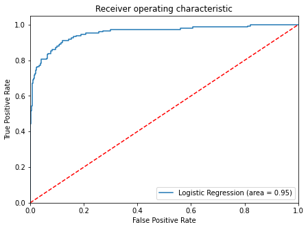

```python
logit_roc_auc_test = roc_auc_score(Y_test, lr.predict_proba(X_test)[:, 1])
fpr, tpr, thresholds = roc_curve(Y_test, lr.predict_proba(X_test)[:, 1])
plt.figure(figsize=(7, 5))
plt.plot(fpr, tpr, label="Logistic Regression (area = %0.2f)" % logit_roc_auc_test)
plt.plot([0, 1], [0, 1], "r--")
plt.xlim([0.0, 1.0])
plt.ylim([0.0, 1.05])
plt.xlabel("False Positive Rate")
plt.ylabel("True Positive Rate")
plt.title("Receiver operating characteristic")
plt.legend(loc="lower right")
plt.show()
```

Logistic Regression model is giving a good performance on training set but the recall is low and can be further improved

- ### Model Performance Improvement

Let's see if the recall score can be improved further, by changing the model threshold using AUC-ROC Curve and Precision Recall cuves

- #### Optimal threshold using AUC-ROC curve

```python
# Optimal threshold as per AUC-ROC curve
# The optimal cut off would be where tpr is high and fpr is low
fpr, tpr, thresholds = roc_curve(Y_train, lr.predict_proba(X_train)[:, 1])

optimal_idx = np.argmax(tpr - fpr)
optimal_threshold_auc_roc = thresholds[optimal_idx]
print(optimal_threshold_auc_roc)
```

```
0.14330397439422862
```

- #### Checking model performance on training set

```python
# checking model performance for this model
log_reg_model_train_perf_threshold_auc_roc = model_performance_classification_sklearn_with_threshold(
    lr, X_train, Y_train, threshold=optimal_threshold_auc_roc
)
print("Training performance:")
log_reg_model_train_perf_threshold_auc_roc
```

```
Training performance:
```

|  | Accuracy | Recall | Precision | F1 |
| --- | --- | --- | --- | --- |
| 0 | 0.933714 | 0.882175 | 0.602062 | 0.715686 |

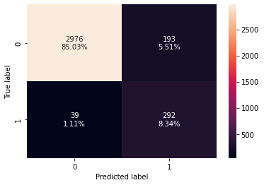

```python
# creating confusion matrix
confusion_matrix_sklearn_with_threshold(
    lr, X_train, Y_train, threshold=optimal_threshold_auc_roc
)
```

- #### Checking model performance on test set

```python
# checking model performance for this model
log_reg_model_test_perf_threshold_auc_roc = model_performance_classification_sklearn_with_threshold(
    lr, X_test, Y_test, threshold=optimal_threshold_auc_roc
)
print("Test performance:")
log_reg_model_test_perf_threshold_auc_roc
```

```
Test performance:
```

|  | Accuracy | Recall | Precision | F1 |
| --- | --- | --- | --- | --- |
| 0 | 0.925333 | 0.812081 | 0.590244 | 0.683616 |

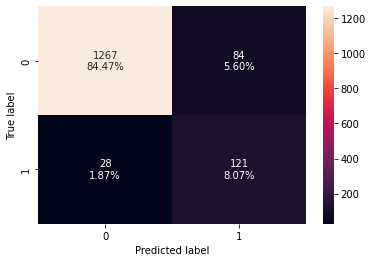

```python
# creating confusion matrix
confusion_matrix_sklearn_with_threshold(
    lr, X_test, Y_test, threshold=optimal_threshold_auc_roc
)
```

Model performace has improved both on the train and test datasets by almost 20% for each case

- #### Optimal threshold using Precision Recall curve

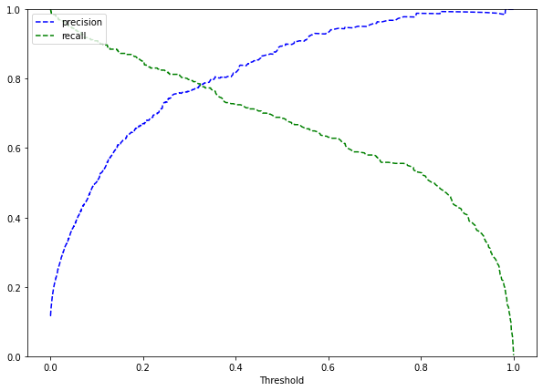

```
Optimal threshold based on the precision recall curve: 0.32352255892053366
```

```python
Y_scores = lr.predict_proba(X_train)[:, 1]
prec, rec, tre = precision_recall_curve(Y_train, Y_scores,)


def plot_prec_recall_vs_tresh(precisions, recalls, thresholds):
    plt.plot(thresholds, precisions[:-1], "b--", label="precision")
    plt.plot(thresholds, recalls[:-1], "g--", label="recall")
    plt.xlabel("Threshold")
    plt.legend(loc="upper left")
    plt.ylim([0, 1])


plt.figure(figsize=(10, 7))
plot_prec_recall_vs_tresh(prec, rec, tre)
plt.show()

for i, threshold in enumerate(tre[:-1]):
    if (rec[i] - prec[i]) * (rec[i + 1] - prec[i + 1]) <= 0:
        optimal_threshold_curve = threshold
        break
print("Optimal threshold based on the precision recall curve:", optimal_threshold_curve)
```

- #### Checking model performance on training set

```python
# checking model performance for this model
log_reg_model_train_perf_threshold_curve = model_performance_classification_sklearn_with_threshold(
    lr, X_train, Y_train, threshold=optimal_threshold_curve
)
print("Training performance:")
log_reg_model_train_perf_threshold_curve
```

```
Training performance:
```

|  | Accuracy | Recall | Precision | F1 |
| --- | --- | --- | --- | --- |
| 0 | 0.958286 | 0.779456 | 0.779456 | 0.779456 |

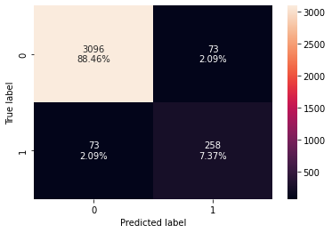

```python
# creating confusion matrix
confusion_matrix_sklearn_with_threshold(
    lr, X_train, Y_train, threshold=optimal_threshold_curve
)
```

#### Checking model performance on test set

```python
# checking model performance for this model
log_reg_model_test_perf_threshold_curve = model_performance_classification_sklearn_with_threshold(
    lr, X_test, Y_test, threshold=optimal_threshold_curve
)
print("Test performance:")
log_reg_model_test_perf_threshold_curve
```

```
Test performance:
```

|  | Accuracy | Recall | Precision | F1 |
| --- | --- | --- | --- | --- |
| 0 | 0.956 | 0.718121 | 0.816794 | 0.764286 |

[figure not shown]

```python
# creating confusion matrix
confusion_matrix_sklearn_with_threshold(
    lr, X_test, Y_test, threshold=optimal_threshold_auc_roc
)
```

- Recall has improved as compared to the initial model.
- Model with threshold as 0.14 was giving a better recall.
- ### Model performance comparison

```python
# training performance comparison

models_train_comp_df = pd.concat(
    [
        log_reg_model_train_perf.T,
        log_reg_model_train_perf_threshold_auc_roc.T,
        log_reg_model_train_perf_threshold_curve.T,
    ],
    axis=1,
)
models_train_comp_df.columns = [
    "Logistic Regression sklearn",
    "Logistic Regression-0.14 Threshold",
    "Logistic Regression-0.32 Threshold",
]

print("Training performance comparison:")
models_train_comp_df
```

```
Training performance comparison:
```

|  | Logistic Regression sklearn | Logistic Regression-0.14 Threshold | Logistic Regression-0.32 Threshold |
| --- | --- | --- | --- |
| Accuracy | 0.962857 | 0.933714 | 0.958286 |
| Recall | 0.685801 | 0.882175 | 0.779456 |
| Precision | 0.897233 | 0.602062 | 0.779456 |
| F1 | 0.777397 | 0.715686 | 0.779456 |

```python
# testing performance comparison

models_test_comp_df = pd.concat(
    [
        log_reg_model_test_perf.T,
        log_reg_model_test_perf_threshold_auc_roc.T,
        log_reg_model_test_perf_threshold_curve.T,
    ],
    axis=1,
)
models_test_comp_df.columns = [
    "Logistic Regression sklearn",
    "Logistic Regression-0.14 Threshold",
    "Logistic Regression-0.32 Threshold",
]

print("Test set performance comparison:")
models_test_comp_df
```

```
Test set performance comparison:
```

|  | Logistic Regression sklearn | Logistic Regression-0.14 Threshold | Logistic Regression-0.32 Threshold |
| --- | --- | --- | --- |
| Accuracy | 0.953333 | 0.925333 | 0.956000 |
| Recall | 0.597315 | 0.812081 | 0.718121 |
| Precision | 0.898990 | 0.590244 | 0.816794 |
| F1 | 0.717742 | 0.683616 | 0.764286 |

## 5. Summary, Conclusios and Business reccomendations

- ### Comparing the best decision tree and logistic regression models

For decision tree the best results were generated by post-pruned model, whereas for logitical regression best results are produced by the model with 0.14 threshold. So we will compare the these two models for both test and train data.

```python
# training performance comparison

models_train_comp_df = pd.concat(
    [
        log_reg_model_train_perf_threshold_auc_roc.T,
        decision_tree_postprune_perf_train.T,
    ],
    axis=1,
)
models_train_comp_df.columns = [
    "Logistic Regression-0.14 Threshold",
    "Decision Tree (Post-Pruning)",
]

print("Training performance comparison:")
models_train_comp_df
```

```
Training performance comparison:
```

|  | Logistic Regression-0.14 Threshold | Decision Tree (Post-Pruning) |
| --- | --- | --- |
| Accuracy | 0.933714 | 0.939143 |
| Recall | 0.882175 | 0.987915 |
| Precision | 0.602062 | 0.610075 |
| F1 | 0.715686 | 0.754325 |

```python
# testing performance comparison

models_test_comp_df = pd.concat(
    [log_reg_model_test_perf_threshold_auc_roc.T, decision_tree_postprune_perf_test.T,],
    axis=1,
)
models_test_comp_df.columns = [
    "Logistic Regression-0.14 Threshold",
    "Decision Tree (Post-Pruning)",
]

print("Test set performance comparison:")
models_test_comp_df
```

```
Test set performance comparison:
```

|  | Logistic Regression-0.14 Threshold | Decision Tree (Post-Pruning) |
| --- | --- | --- |
| Accuracy | 0.925333 | 0.938000 |
| Recall | 0.812081 | 0.979866 |
| Precision | 0.590244 | 0.618644 |
| F1 | 0.683616 | 0.758442 |